# Nejdřív si plsky nainstaluj tyto balíčky, anžto budou pro nás klíčové

# - následující věci musim uvést takhle, nebude to vypadat jako R kód, ale jinak to nejde vyexportovat

install.packages(“tm”) # for text mining install.packages(“SnowballC”) # for text stemming install.packages(“wordcloud”) # word-cloud generator install.packages(“RColorBrewer”) # color palettes

# Násladně si je nahraj

```r
library("tm")
```

```r
library("SnowballC")
library("wordcloud")
library("RColorBrewer")
```

# Nejdřív si stáhni tedy nějakou knihu, třeba z library genesis. Ta bude v .epub formátu. My chceme .txt formát. K převodu použij třeba tuto stránku: https://convertio.co/epub-txt/

# dál chcem tenhle soubor naloudovat, to uděláme tímto příkazem

```r
JménoTvéhoVyvoleného <- readLines(file.choose())
```

# Nelekni se, otevře se ti normálně finder a klikneš si na ten svůj souborek

# Dalším krokem je udělání z toho .txt korpus! To je naprosto klíčový

```r
KorpusTvéhoVyvoleného <- Corpus(VectorSource(JménoTvéhoVyvoleného))
```

#po téhle náročné aktivity to čekni, opět neuvádím jako kód, aby to nebyl zasraně dlouhej dokument:-)

inspect(KorpusTvéhoVyvoleného)

# teď budeme tenhle korpus čistit a dělat z něj obecně partnera se kterým se nám bude v životě lépe vycházet. k tomu použijeme skvělou knihovnu tm_map, níže najdeš fajnovky, který z ní můžeš tahat

# lower case všeho

```r
KorpusTvéhoVyvoleného <- tm_map(KorpusTvéhoVyvoleného, content_transformer(tolower))
```

# odstraň čísla, čísla smrdí

```r
KorpusTvéhoVyvoleného <- tm_map(KorpusTvéhoVyvoleného, removeNumbers)
```

# odstraň anglický stopwords

```r
KorpusTvéhoVyvoleného <- tm_map(KorpusTvéhoVyvoleného, removeWords, stopwords("english"))
```

# taky si můžeš odstranit svoje vlastní slova :O… třeba když se ti nelíbí něčí jméno, tak ho prostě smaž! podle mě třeba Radek je fakt vošklivý jméno…

```r
KorpusTvéhoVyvoleného <- tm_map(KorpusTvéhoVyvoleného, removeWords, c("Radek", "Šlerka", "Josef", "povinnosti"))
```

# co nám dělá problém největší? jako čechům? aha? tak to dáme pryč!

```r
KorpusTvéhoVyvoleného <- tm_map(KorpusTvéhoVyvoleného, removePunctuation)
```

# pak dáme pryč mezery

```r
KorpusTvéhoVyvoleného <- tm_map(KorpusTvéhoVyvoleného, stripWhitespace)
```

# tím máme text už docela očištění a vznikl nám tolik potřebný Lebensraum. Stojíme před důležitou volbou, zda vstoupit do Matrixu. Což chceme. Vezmeme si červenou pilulku a uděláme z našeho korpusu tabulku, která obsahuje frekvenci jednotlivých slov

```r
VolímČERVENOU <- TermDocumentMatrix(KorpusTvéhoVyvoleného)
```

# pak mu přidáme nějaký ty charakteristiky, to ti vysvětlovat nebudu, prostě to chceš!

```r
m <- as.matrix(VolímČERVENOU)
v <- sort(rowSums(m),decreasing=TRUE)
d <- data.frame(word = names(v),freq=v)
head(d, 10)
```

```
##      word freq
## said said  598
## like like  428
## one   one  391
## can   can  300
## time time  298
## know know  288
## old   old  254
## say   say  240
## will will  227
## back back  222
```

# voalá a máš vytištěných top 10 nejčastějších slov. teď už moc nestíhám, za 20 minut bych se měl osprchovat, abych nejel do kanclu a nebyl porostlej pomalu mechem - A PROTO - pojďme si vytvořit Word cloud!

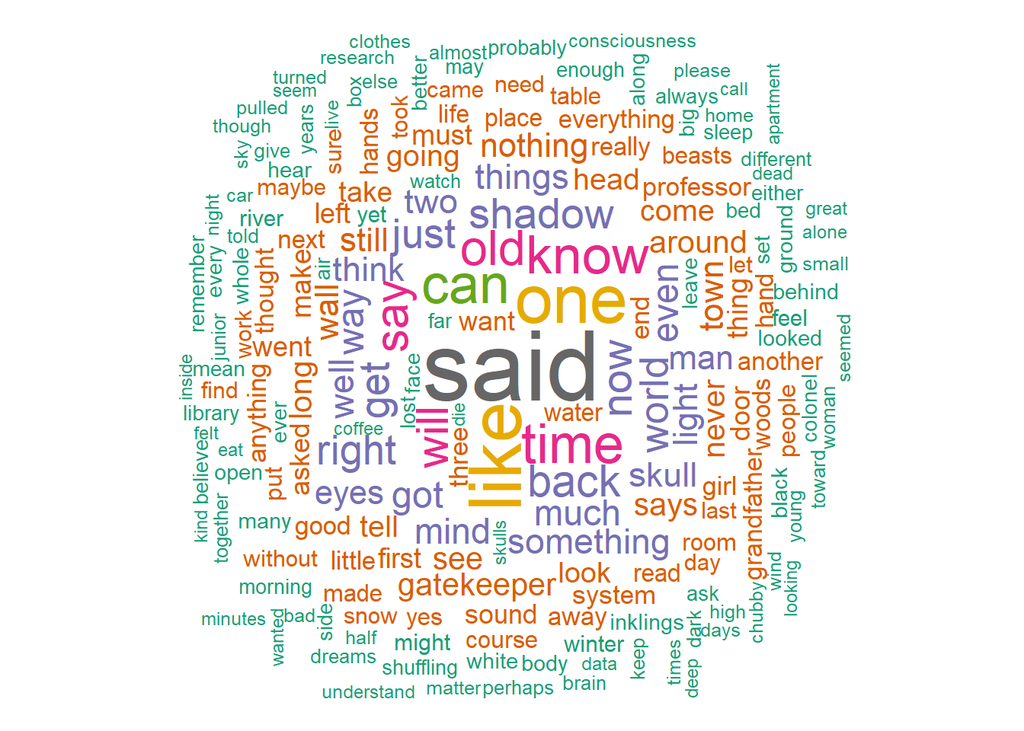

```r
set.seed(1234)
wordcloud(words = d$word, freq = d$freq, min.freq = 1,
          max.words=200, random.order=FALSE, rot.per=0.35,
          colors=brewer.pal(8, "Dark2"))
```

# co která funkce u word cloudu dělá?

# words : z jakejch slov chceme matrix dělat

# freq : jejich frekvence

# min.freq : je to treshhold kdy vyhodíš málo častý slova

# max.words : maximum number of words to be plotted

# random.order : chcem slova zobrazovat náhodně nebo budou velký podle toho, kolik jich tam je a odrážet tak ve wordcloudu svůj počet?

# rot.per : jak dlouhý slova budou zobrazovaný vertikálně

# colors : zabarví slova od nejčastěji zobrazovaných po nejméně. dokumentace k word cloudu a další funkce a možnosti najdeš zde: https://cran.r-project.org/web/packages/wordcloud/wordcloud.pdf

# další zábavné funkce mohou být třeba frekvenci výrazů a jejich asociace. můžem se podívat třeba na frekvenci slov v matrixu - tenhle příkaz nám ukáže slova, který tam jsou alespoň dvěstěkrát

```r
findFreqTerms(VolímČERVENOU, lowfreq = 200)
```

```
##  [1] "shadow" "time"   "just"   "know"   "one"    "like"   "get"    "back"
##  [9] "right"  "say"    "can"    "now"    "said"   "old"    "will"
```

# no a pak třeba můžeš najít nejčastějí asociace k určitejm slovům. já zpracovával murakamiho knížku, která se jmenovala konec světa, tak jsem vybral termín “world”, ať víme, jestli tam svět dělá i něco jinýho, než aby akorát končil.

```r
findAssocs(VolímČERVENOU, terms = "world", corlimit = 0.3)
```

```
## $world
##  end
## 0.38
```

# A na týhle vlně končim. Svět skončí. Musím do práce. Pláču. Vidím stíny. Čas. A jenom vím, že jsem jedno zrnko písku!